# Trade Count Regression

Tobi Bosede

December 15, 2016

550.700

```r
library(mgcv)
library(ggplot2)
```

```r
setwd("C:/Users/aniverb/Documents/Grad_School/JHU/700")
trade_data=read.table("trades_count_regression_2016-11-18.txt", header=T)
trade_data=trade_data[order(trade_data$Date),]
head(trade_data)
```

```
##     ProductName   Maturity       Date TimeToMaturity DayOfTheWeek
## 1            6E 2016-06-13 2016-05-02             42          Mon
## 30           6E 2016-09-19 2016-05-02            140          Mon
## 123          6E 2016-12-19 2016-05-02            231          Mon
## 445          CL 2016-08-22 2016-05-02            112          Mon
## 514          CL 2016-09-20 2016-05-02            141          Mon
## 595          CL 2016-10-20 2016-05-02            171          Mon
##     DayofMonth ProductType Day DayTradeTotal TradeTotBCTrans
## 1            2          FX   1        105173       17.034718
## 30           2          FX   1           286        6.798459
## 123          2          FX   1            17        3.102611
## 445          2      Energy   1          2004        9.759987
## 514          2      Energy   1           899        8.496351
## 595          2      Energy   1           218        6.413661
##     TradeTotLogTrans
## 1          11.563362
## 30          5.655992
## 123         2.833213
## 445         7.602900
## 514         6.801283
## 595         5.384495
```

```r
#use only half of data randomly split into train and test
n=dim(trade_data)[1]/2
reg_data=trade_data[1:n, ]
set.seed(12-1-16)
train_id=sample(1:n, n)[1:floor(n/2)]
train=reg_data[train_id, ]
test=reg_data[-train_id, ]
```

Build linear regression model with penalized cubic spline. Spline parameters found by cross validation.

```r
model1 <- gam(TradeTotBCTrans ~ s(TimeToMaturity, bs="cr") + s(DayofMonth, bs="cr") + s(Day, bs="cr") + factor(ProductType) + factor(ProductName) + factor(DayOfTheWeek), family=gaussian(), data = train, method="GCV.Cp", select=TRUE)
summary(model1)
```

```
##
## Family: gaussian
## Link function: identity
##
## Formula:
## TradeTotBCTrans ~ s(TimeToMaturity, bs = "cr") + s(DayofMonth,
##     bs = "cr") + s(Day, bs = "cr") + factor(ProductType) + factor(ProductName) +
##     factor(DayOfTheWeek)
##
## Parametric coefficients:
##                           Estimate Std. Error t value Pr(>|t|)
## (Intercept)               10.28386    0.18168  56.604  < 2e-16 ***
## factor(ProductType)Bond    1.85471    0.17040  10.884  < 2e-16 ***
## factor(ProductType)Energy  0.86315    0.13868   6.224 5.81e-10 ***
## factor(ProductType)FX      0.38051    0.40759   0.934 0.350632
## factor(ProductType)Index   1.00893    0.19367   5.210 2.07e-07 ***
## factor(ProductType)Metal  -0.89671    0.15683  -5.718 1.23e-08 ***
## factor(ProductName)CL      1.40946    0.24512   5.750 1.02e-08 ***
## factor(ProductName)ES      2.70785    0.34736   7.795 9.90e-15 ***
## factor(ProductName)GC      0.06340    0.23005   0.276 0.782889
## factor(ProductName)GE      3.59500    0.54455   6.602 5.10e-11 ***
## factor(ProductName)HO     -1.74356    0.30917  -5.640 1.93e-08 ***
## factor(ProductName)KE     -0.35993    0.39692  -0.907 0.364600
## factor(ProductName)NG      0.29594    0.22767   1.300 0.193796
## factor(ProductName)NQ     -0.06467    0.38057  -0.170 0.865085
## factor(ProductName)RB     -0.84225    0.23623  -3.565 0.000371 ***
## factor(ProductName)SI     -0.96011    0.24529  -3.914 9.35e-05 ***
## factor(ProductName)UB     -0.24036    0.51806  -0.464 0.642720
## factor(ProductName)YM     -1.63426    0.37360  -4.374 1.28e-05 ***
## factor(ProductName)ZB     -0.34587    0.44307  -0.781 0.435115
## factor(ProductName)ZC      4.63530    0.37069  12.504  < 2e-16 ***
## factor(ProductName)ZF      1.66764    0.48748   3.421 0.000636 ***
## factor(ProductName)ZL      0.01288    0.32740   0.039 0.968621
## factor(ProductName)ZM      0.54760    0.31258   1.752 0.079939 .
## factor(ProductName)ZN      1.76751    0.47372   3.731 0.000196 ***
## factor(ProductName)ZQ     -0.34237    0.28328  -1.209 0.226945
## factor(ProductName)ZT      1.09171    0.47739   2.287 0.022301 *
## factor(ProductName)ZW      2.23743    0.39930   5.603 2.37e-08 ***
## factor(DayOfTheWeek)Mon    0.17694    0.26361   0.671 0.502149
## factor(DayOfTheWeek)Thu   -0.10918    0.25861  -0.422 0.672939
## factor(DayOfTheWeek)Tue    0.22308    0.25149   0.887 0.375170
## factor(DayOfTheWeek)Wed    0.33754    0.25439   1.327 0.184700
## ---
## Signif. codes:  0 '***' 0.001 '**' 0.01 '*' 0.05 '.' 0.1 ' ' 1
##
## Approximate significance of smooth terms:
##                     edf Ref.df      F  p-value
## s(TimeToMaturity) 7.873      9 87.655  < 2e-16 ***
## s(DayofMonth)     8.574      9  6.161 5.87e-10 ***
## s(Day)            3.756      9  2.597 1.89e-05 ***
## ---
## Signif. codes:  0 '***' 0.001 '**' 0.01 '*' 0.05 '.' 0.1 ' ' 1
##
## Rank: 53/58
## R-sq.(adj) =  0.381   Deviance explained = 39.4%
## GCV = 13.522  Scale est. = 13.239    n = 2206
```

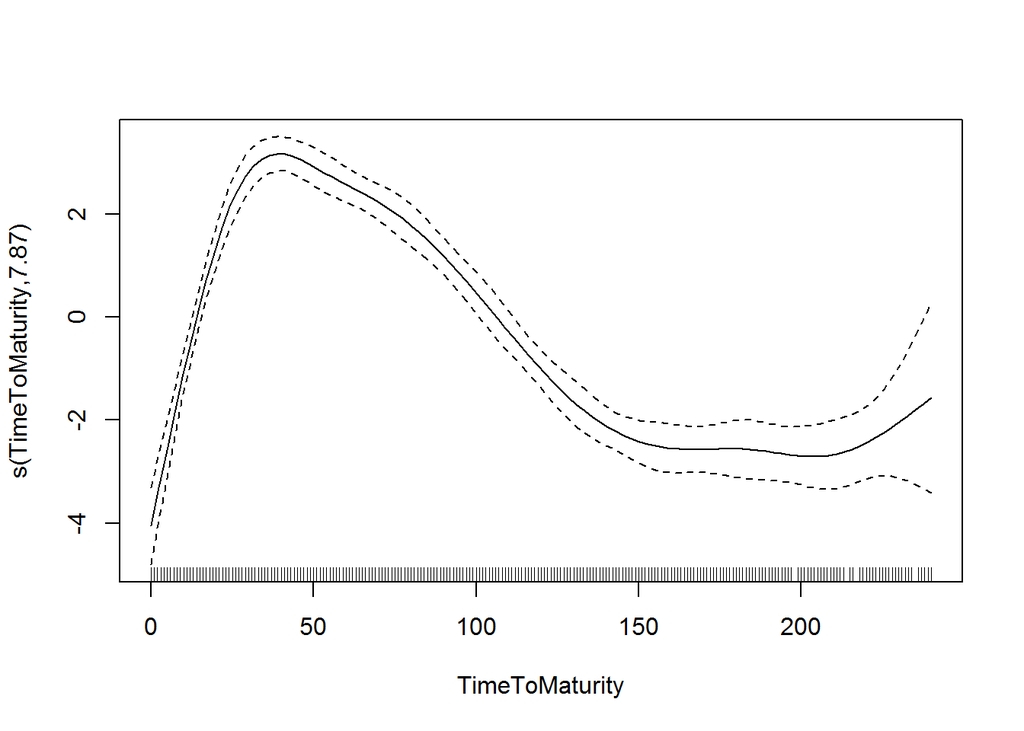

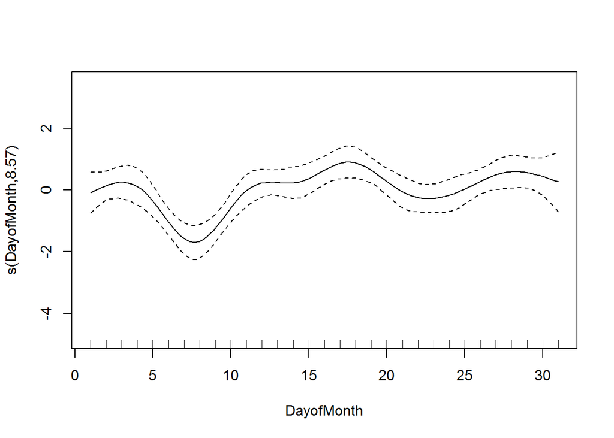

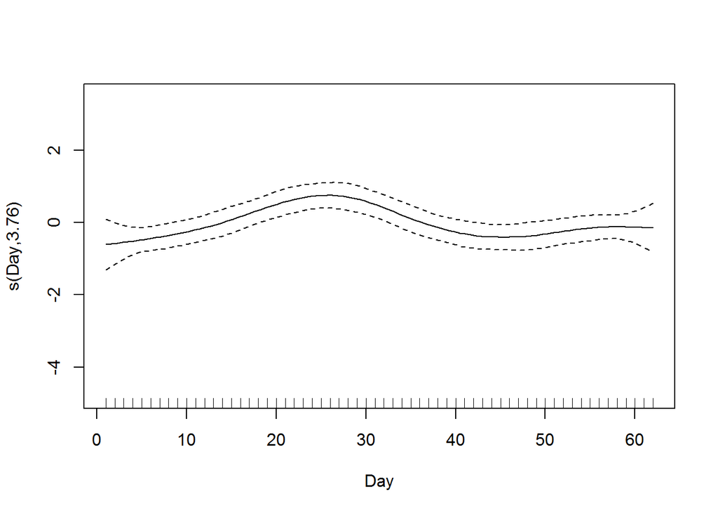

```r
plot(model1)
```

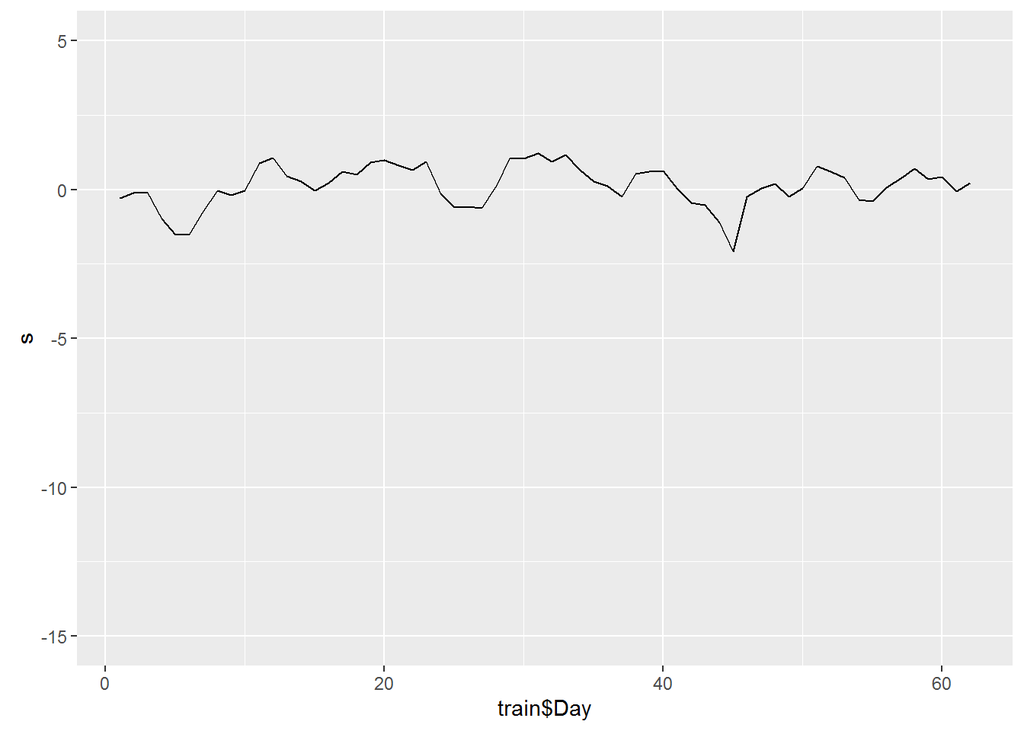

```r
p <- predict(model1, type="lpmatrix")
beta <- coef(model1)[grepl("Day", names(coef(model1)))]
s <- p[,grepl("Day", colnames(p))] %*% beta
ggplot(data=cbind.data.frame(s, train$Day), aes(x=train$Day, y=s, ymin = -15, ymax = 5)) + geom_line()
```

```r
optFrame=cbind.data.frame(s, train)
sub=subset(optFrame, train$Day<35)
sub[which(sub$s==max(sub$s))[1],]
```

```
##             s ProductName   Maturity       Date TimeToMaturity
## 6344 1.208905          ZF 2016-09-30 2016-06-15            107
##      DayOfTheWeek DayofMonth ProductType Day DayTradeTotal TradeTotBCTrans
## 6344          Wed         15        Bond  31        630741        20.97243
##      TradeTotLogTrans
## 6344         13.35465
```

```r
sub=subset(optFrame, train$Day>35)
sub[which(sub$s==min(sub$s))[1],]
```

```
##              s ProductName   Maturity       Date TimeToMaturity
## 8558 -2.090545          ZW 2016-07-14 2016-07-07              7
##      DayOfTheWeek DayofMonth ProductType Day DayTradeTotal TradeTotBCTrans
## 8558          Thu          7         Agr  45             1               0
##      TradeTotLogTrans
## 8558                0
```

```r
trainMon=subset(optFrame, train$DayOfTheWeek=="Mon")
dim(trainMon)
```

```
## [1] 426  12
```

```r
trainTue=subset(optFrame, train$DayOfTheWeek=="Tue")
dim(trainTue)
```

```
## [1] 502  12
```

```r
trainWed=subset(optFrame, train$DayOfTheWeek=="Wed")
dim(trainWed)
```

```
## [1] 447  12
```

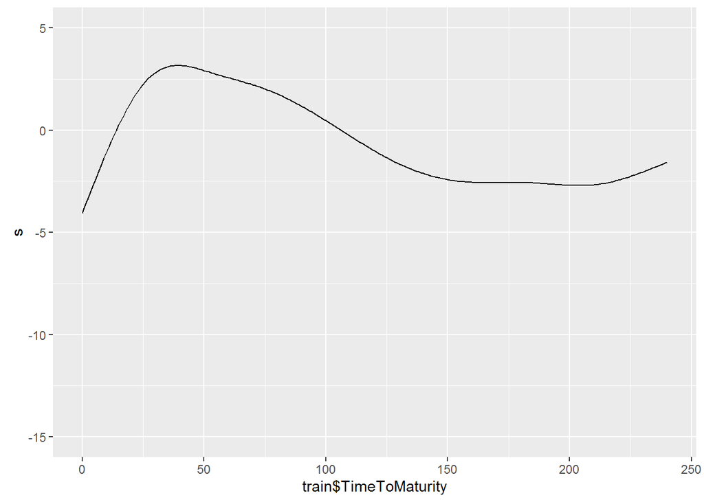

```r
beta <- coef(model1)[grepl("TimeToMaturity", names(coef(model1)))]
s <- p[,grepl("TimeToMaturity", colnames(p))] %*% beta
ggplot(data=cbind.data.frame(s, train$TimeToMaturity), aes(x=train$TimeToMaturity, y=s, ymin = -15, ymax = 5)) + geom_line()
```

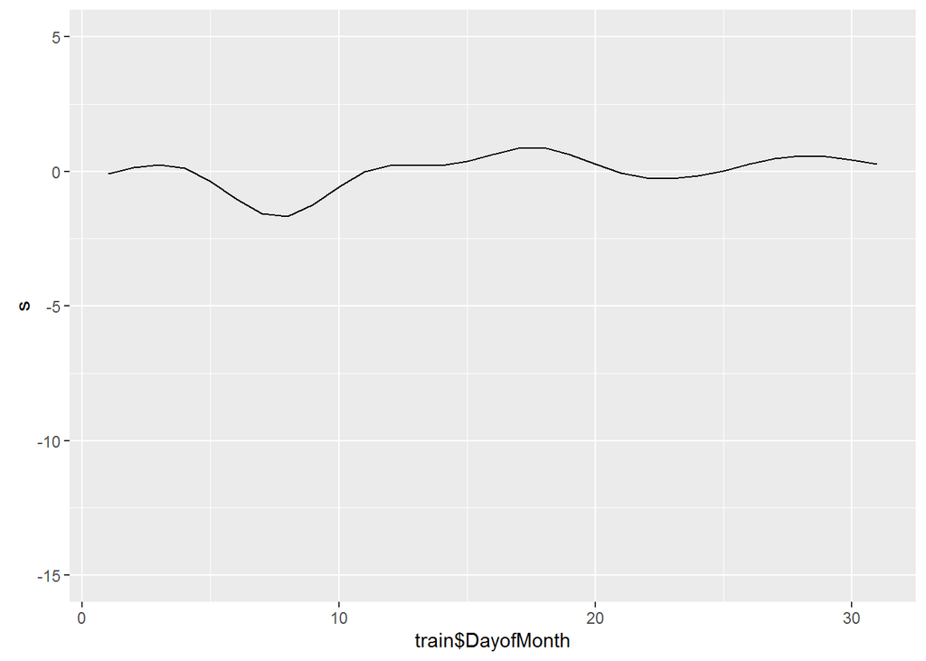

```r
beta <- coef(model1)[grepl("DayofMonth", names(coef(model1)))]
s <- p[,grepl("DayofMonth", colnames(p))] %*% beta
ggplot(data=cbind.data.frame(s, train$DayofMonth), aes(x=train$DayofMonth, y=s, ymin = -15, ymax = 5)) + geom_line()
```

```r
model1$coefficients
```

```
##               (Intercept)   factor(ProductType)Bond
##               10.28386175                1.85470504
## factor(ProductType)Energy     factor(ProductType)FX
##                0.86314880                0.38051161
##  factor(ProductType)Index  factor(ProductType)Metal
##                1.00892861               -0.89671149
##     factor(ProductName)CL     factor(ProductName)ES
##                1.40946102                2.70785428
##     factor(ProductName)GC     factor(ProductName)GE
##                0.06339907                3.59499836
##     factor(ProductName)HO     factor(ProductName)KE
##               -1.74355981               -0.35993285
##     factor(ProductName)NG     factor(ProductName)NQ
##                0.29593634               -0.06466928
##     factor(ProductName)RB     factor(ProductName)SI
##               -0.84224855               -0.96011056
##     factor(ProductName)UB     factor(ProductName)YM
##               -0.24036083               -1.63425638
##     factor(ProductName)ZB     factor(ProductName)ZC
##               -0.34586931                4.63530220
##     factor(ProductName)ZF     factor(ProductName)ZL
##                1.66764116                0.01288055
##     factor(ProductName)ZM     factor(ProductName)ZN
##                0.54760031                1.76751397
##     factor(ProductName)ZQ     factor(ProductName)ZT
##               -0.34236959                1.09170945
##     factor(ProductName)ZW   factor(DayOfTheWeek)Mon
##                2.23742897                0.17694385
##   factor(DayOfTheWeek)Thu   factor(DayOfTheWeek)Tue
##               -0.10917987                0.22307838
##   factor(DayOfTheWeek)Wed       s(TimeToMaturity).1
##                0.33753724                3.94925517
##       s(TimeToMaturity).2       s(TimeToMaturity).3
##                4.33392207                3.23231356
##       s(TimeToMaturity).4       s(TimeToMaturity).5
##                1.33501883               -0.44086182
##       s(TimeToMaturity).6       s(TimeToMaturity).7
##               -1.47601705               -1.90989546
##       s(TimeToMaturity).8       s(TimeToMaturity).9
##               -2.08787752               -1.47087806
##           s(DayofMonth).1           s(DayofMonth).2
##                0.01959513               -1.68092521
##           s(DayofMonth).3           s(DayofMonth).4
##                0.01310052                0.27867619
##           s(DayofMonth).5           s(DayofMonth).6
##                0.93151797               -0.03819926
##           s(DayofMonth).7           s(DayofMonth).8
##               -0.09032811                0.59675653
##           s(DayofMonth).9                  s(Day).1
##                0.26927381               -0.16001030
##                  s(Day).2                  s(Day).3
##                0.24488456                0.78380679
##                  s(Day).4                  s(Day).5
##                0.89260460                0.29687922
##                  s(Day).6                  s(Day).7
##               -0.17660527               -0.20525741
##                  s(Day).8                  s(Day).9
##                0.01855708               -0.09555437
```

```r
model1$sp #spline parameters
```

```
## s(TimeToMaturity)1 s(TimeToMaturity)2     s(DayofMonth)1
##       2.165999e-01       2.407811e+00       6.244003e-02
##     s(DayofMonth)2            s(Day)1            s(Day)2
##       5.496678e+00       2.838373e+00       5.500380e+07
```

Unsurprisingly, the below residuals are quite large, especially since they are for the box cox transformed trade counts. However they seem constant so an assumption of the linear regression model is fufilled.

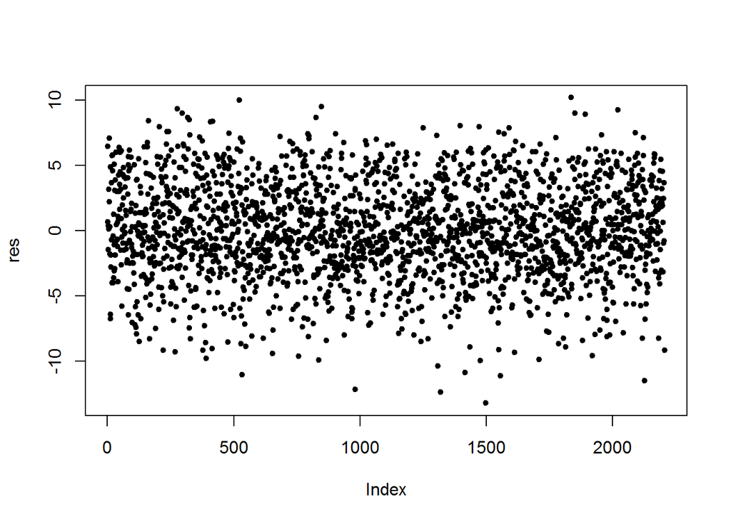

```r
res=model1$residuals
plot(res, pch=20)
```

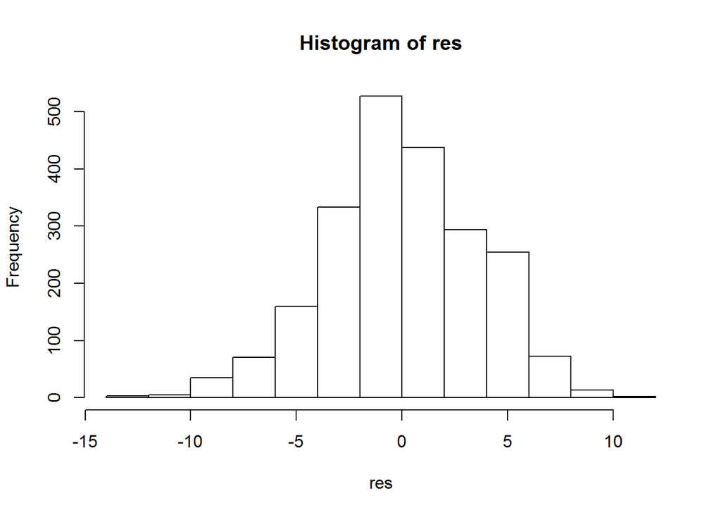

```r
hist(res)
```

Actual values are black, predicted values are red

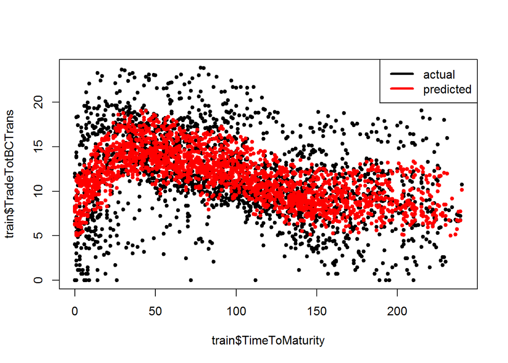

```r
trainPred=model1$fitted.values
plot(train$TimeToMaturity, train$TradeTotBCTrans, pch=20, ylim=c(min(train$TradeTotBCTrans, trainPred), max(train$TradeTotBCTrans, trainPred)))
points(train$TimeToMaturity, trainPred, col="red", pch=20)
legend("topright", c("actual", "predicted"),lwd=c(3,3),col=c("black", "red"))
```

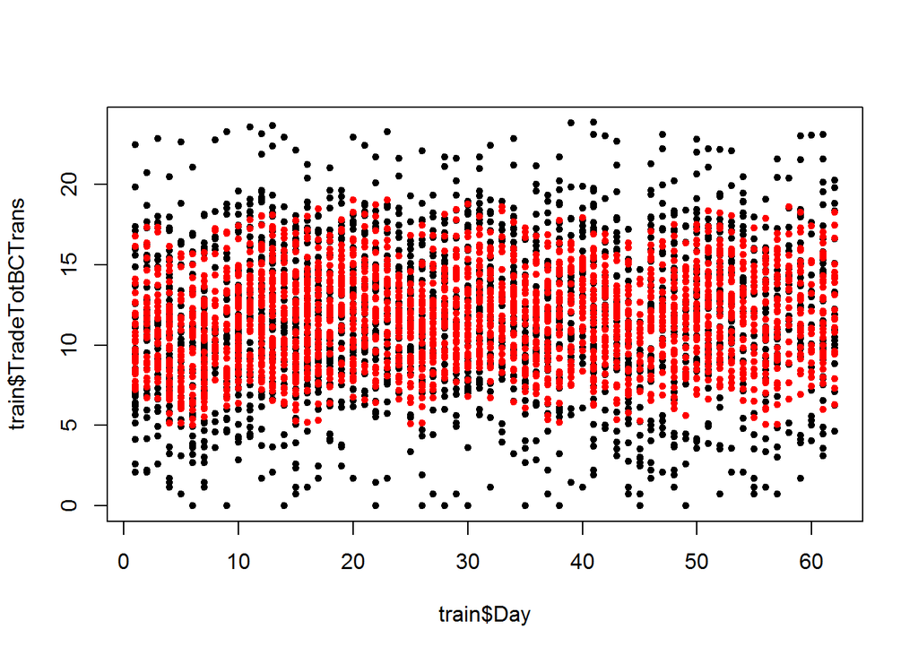

```r
plot(train$Day, train$TradeTotBCTrans, pch=20, ylim=c(min(train$TradeTotBCTrans, trainPred), max(train$TradeTotBCTrans, trainPred)))
points(train$Day, trainPred, col="red", pch=20)
```

Nice thing about this model is that its performance remains just as bad on the test data. The point being that at least it does not perform worse on new data.

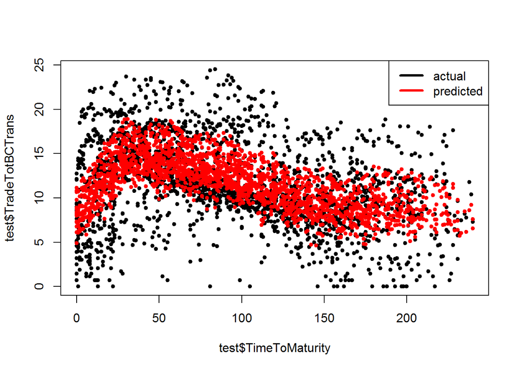

```r
testPred <- predict(model1, test)

plot(test$TimeToMaturity, test$TradeTotBCTrans, pch=20, ylim=c(min(test$TradeTotBCTrans, testPred), max(test$TradeTotBCTrans, testPred)))
points(test$TimeToMaturity, testPred, col="red", pch=20)
legend("topright", c("actual", "predicted"),lwd=c(3,3),col=c("black", "red"))
```

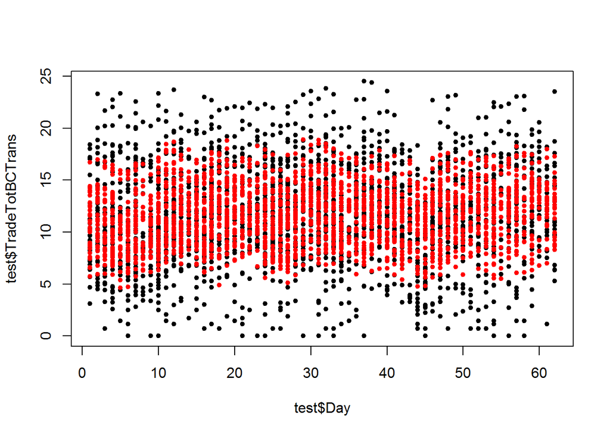

```r
plot(test$Day, test$TradeTotBCTrans, pch=20, ylim=c(min(test$TradeTotBCTrans, testPred), max(test$TradeTotBCTrans, testPred)))
points(test$Day, testPred, col="red", pch=20)
```

Model was only trained on 1/4 of data so only testing on 1/4 of future data.

```r
new_data=trade_data[(n+1):dim(trade_data)[1], ]
set.seed(1-10-17)
newdata_id=sample(1:n, n)[1:floor(n/2)]
new_data1=new_data[newdata_id, ]
head(new_data1)
```

```
##      ProductName   Maturity       Date TimeToMaturity DayOfTheWeek
## 7552          ZN 2016-12-20 2016-09-14             97          Wed
## 2184          GE 2016-12-19 2016-09-21             89          Wed
## 8436          ZT 2016-12-30 2016-08-08            144          Mon
## 3970          NQ 2016-09-16 2016-08-19             28          Fri
## 5203          SI 2017-01-27 2016-10-07            112          Fri
## 6859          ZL 2016-12-14 2016-11-08             36          Tue
##      DayofMonth ProductType Day DayTradeTotal TradeTotBCTrans
## 7552         14        Bond  92        744160      21.3589021
## 2184         21          FX  97        328774      19.4883910
## 8436          8        Bond  66             2       0.7085481
## 3970         19       Index  75        176731      18.1301803
## 5203          7       Metal 109            42       4.2158577
## 6859          8         Agr 131         30637      14.5711523
##      TradeTotLogTrans
## 7552       13.5200113
## 2184       12.7031259
## 8436        0.6931472
## 3970       12.0823841
## 5203        3.7376696
## 6859       10.3299637
```

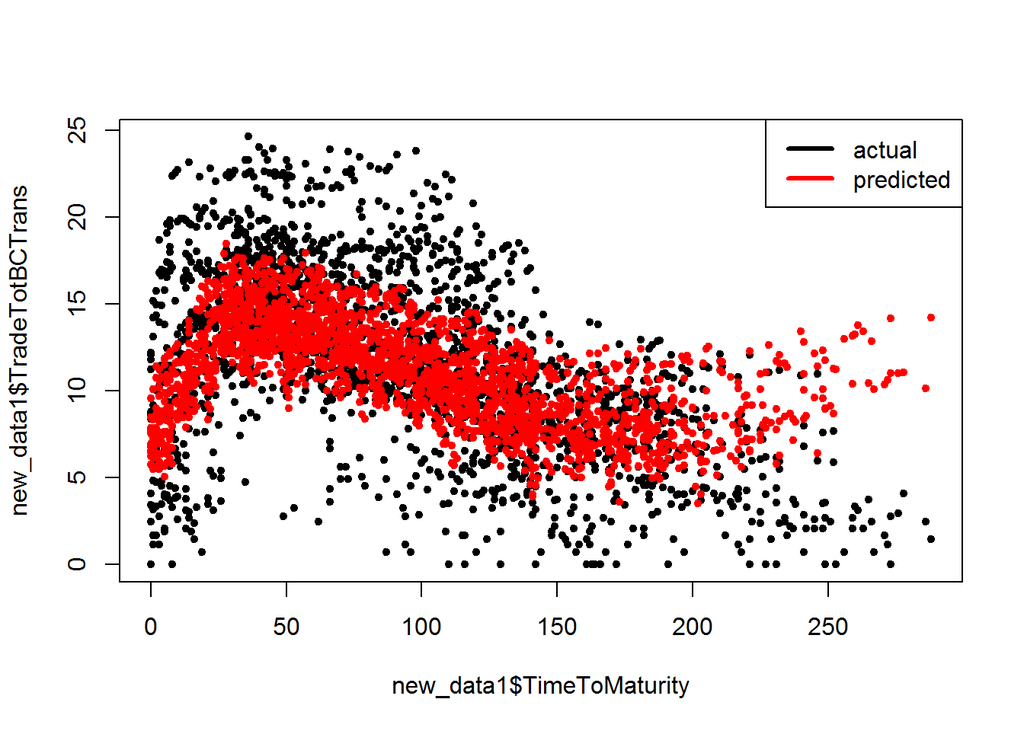

```r
new_data2=new_data[-newdata_id, ] #not used
new_data1Pred <- predict(model1, new_data1)
new_data1["Prediction"]=new_data1Pred
plot(new_data1$TimeToMaturity, new_data1$TradeTotBCTrans, pch=20, ylim=c(min(new_data1$TradeTotBCTrans, new_data1Pred), max(new_data1$TradeTotBCTrans, new_data1Pred)))
points(new_data1$TimeToMaturity, new_data1$Prediction, col="red", pch=20)
legend("topright", c("actual", "predicted"),lwd=c(3,3),col=c("black", "red"))
```

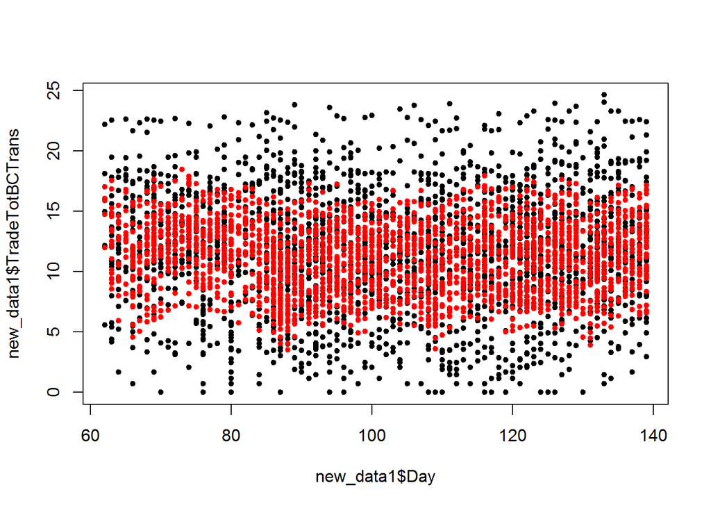

```r
plot(new_data1$Day, new_data1$TradeTotBCTrans, pch=20, ylim=c(min(new_data1$TradeTotBCTrans, new_data1Pred), max(new_data1$TradeTotBCTrans, new_data1Pred)))
points(new_data1$Day, new_data1$Prediction, col="red", pch=20)
```

```r
types=c('Metal', 'Bond', 'Agr', 'Energy', 'Index', 'FX')
MAEone_mod=c()
medians=c()
count=0
for (type in types){
  count=count+1
  typsub=subset(new_data1, ProductType==type)
  MAEone_mod[count]= mean(abs(typsub$TradeTotBCTrans-typsub$Prediction))
  medians[count]=median(typsub$TradeTotBCTrans)
}
```

Creating models for each product type.

```
## Metal
## Family: gaussian
## Link function: identity
##
## Formula:
## TradeTotBCTrans ~ s(TimeToMaturity, bs = "cr") + s(DayofMonth,
##     bs = "cr") + s(Day, bs = "cr") + factor(ProductName) + factor(DayOfTheWeek)
##
## Parametric coefficients:
##                         Estimate Std. Error t value Pr(>|t|)
## (Intercept)               9.2019     0.4994  18.428   <2e-16 ***
## factor(ProductName)SI    -0.5580     0.3942  -1.415    0.158
## factor(DayOfTheWeek)Mon  -0.1104     0.6538  -0.169    0.866
## factor(DayOfTheWeek)Thu  -0.0456     0.6393  -0.071    0.943
## factor(DayOfTheWeek)Tue   0.3003     0.6218   0.483    0.630
## factor(DayOfTheWeek)Wed   0.6735     0.6296   1.070    0.286
## ---
## Signif. codes:  0 '***' 0.001 '**' 0.01 '*' 0.05 '.' 0.1 ' ' 1
##
## Approximate significance of smooth terms:
##                      edf Ref.df      F p-value
## s(TimeToMaturity) 7.8003      9 32.882 < 2e-16 ***
## s(DayofMonth)     0.5152      3  0.406   0.124
## s(Day)            0.9312      2  8.227 2.7e-05 ***
## ---
## Signif. codes:  0 '***' 0.001 '**' 0.01 '*' 0.05 '.' 0.1 ' ' 1
##
## R-sq.(adj) =  0.537   Deviance explained = 56.2%
## GCV =   10.6  Scale est. = 9.9973    n = 268
```

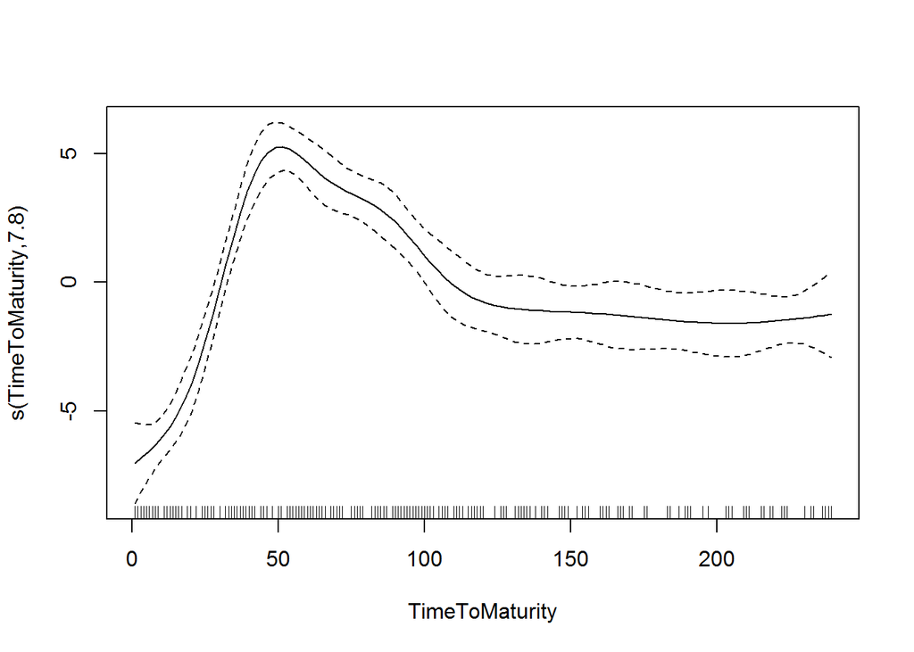

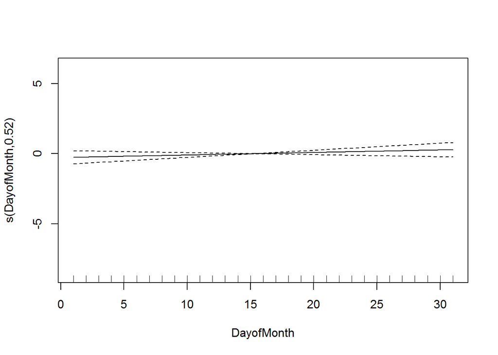

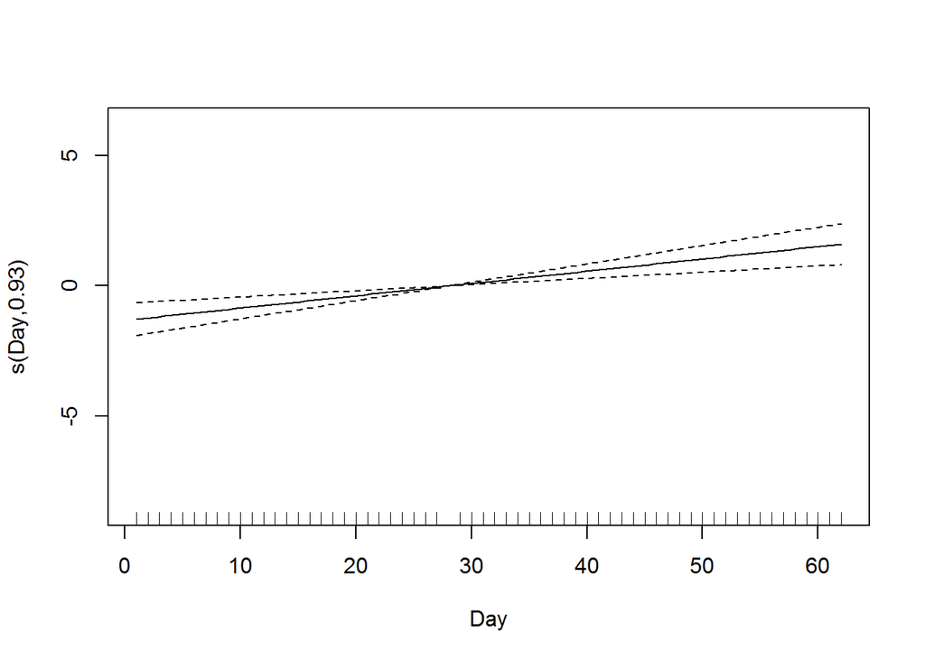

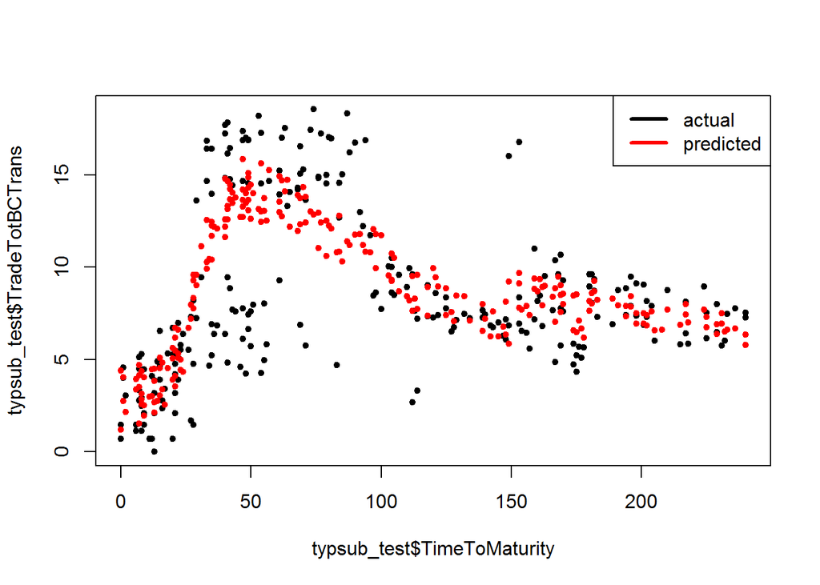

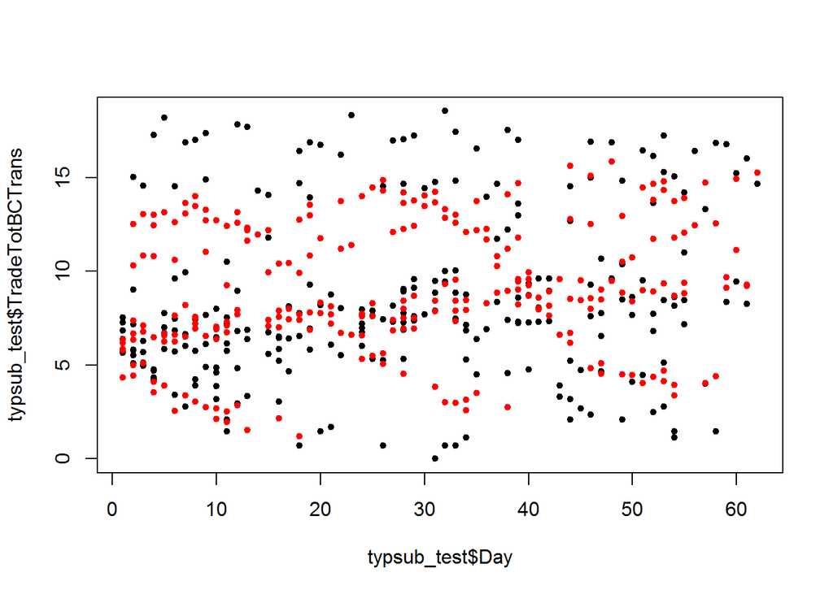

```
## Metal
```

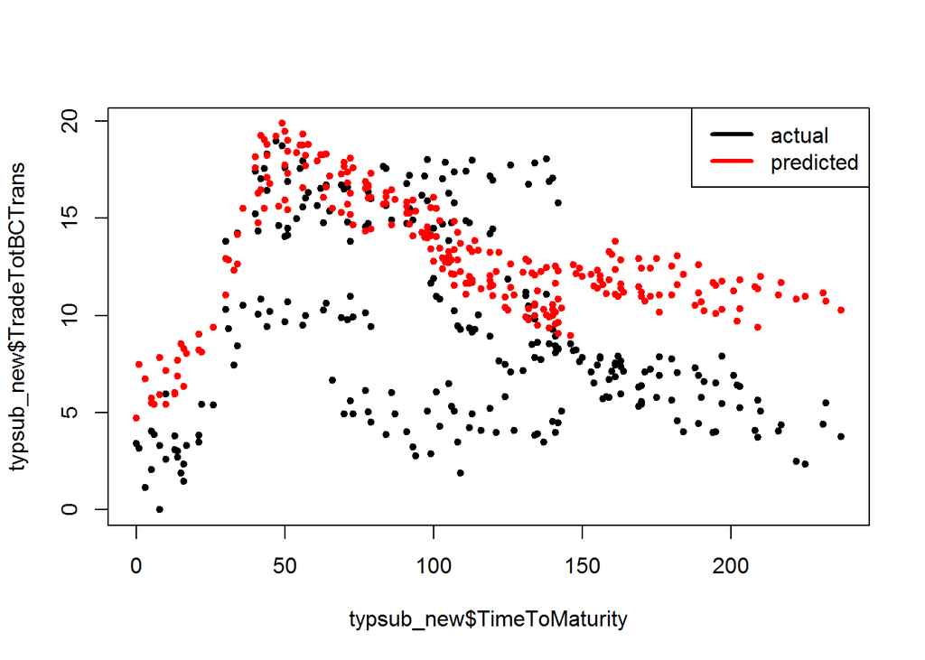

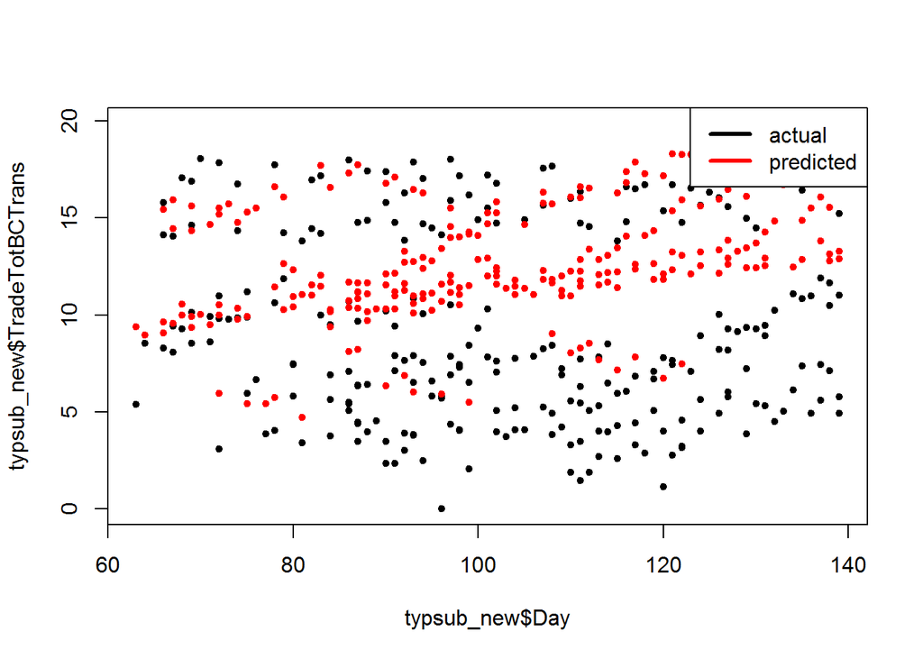

```
##        ProductName   Maturity       Date TimeToMaturity DayOfTheWeek
## 5203            SI 2017-01-27 2016-10-07            112          Fri
## 5203.1          SI 2017-01-27 2016-10-07            112          Fri
## 5203.2          SI 2017-01-27 2016-10-07            112          Fri
## 5203.3          SI 2017-01-27 2016-10-07            112          Fri
## 5203.4          SI 2017-01-27 2016-10-07            112          Fri
## 5203.5          SI 2017-01-27 2016-10-07            112          Fri
##        DayofMonth ProductType Day DayTradeTotal TradeTotBCTrans
## 5203            7       Metal  32            42        4.215858
## 5203.1          7       Metal  49            42        4.215858
## 5203.2          7       Metal  86            42        4.215858
## 5203.3          7       Metal  22            42        4.215858
## 5203.4          7       Metal  32            42        4.215858
## 5203.5          7       Metal  45            42        4.215858
##        TradeTotLogTrans Prediction
## 5203            3.73767   12.01613
## 5203.1          3.73767   12.01613
## 5203.2          3.73767   12.01613
## 5203.3          3.73767   12.01613
## 5203.4          3.73767   12.01613
## 5203.5          3.73767   12.01613
```

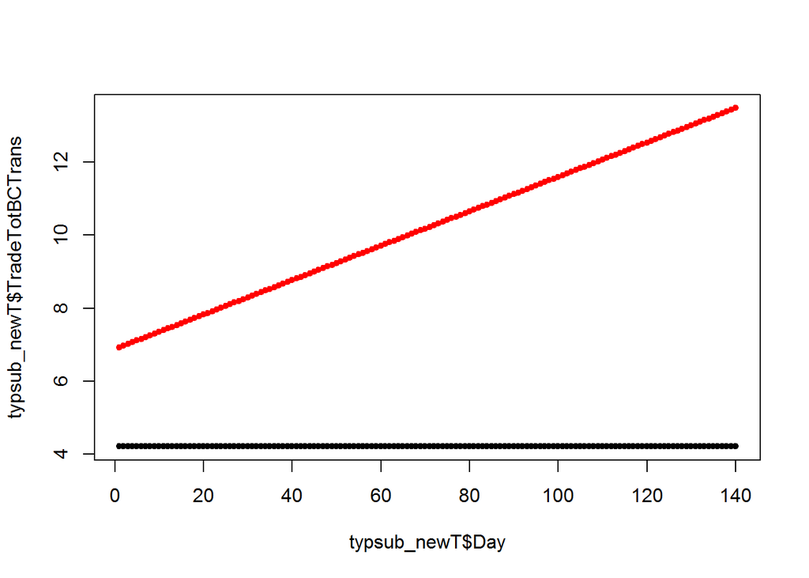

```
## Bond
## Family: gaussian
## Link function: identity
##
## Formula:
## TradeTotBCTrans ~ s(TimeToMaturity, bs = "cr") + s(DayofMonth,
##     bs = "cr") + s(Day, bs = "cr") + factor(ProductName) + factor(DayOfTheWeek)
##
## Parametric coefficients:
##                         Estimate Std. Error t value Pr(>|t|)
## (Intercept)             10.65145    0.44666  23.847  < 2e-16 ***
## factor(ProductName)UB    0.85420    0.63197   1.352  0.17705
## factor(ProductName)ZB    1.46745    0.55009   2.668  0.00787 **
## factor(ProductName)ZF    3.25477    0.59840   5.439 8.10e-08 ***
## factor(ProductName)ZN    3.65155    0.58230   6.271 7.31e-10 ***
## factor(ProductName)ZQ    1.14179    0.39901   2.862  0.00438 **
## factor(ProductName)ZT    2.41708    0.58440   4.136 4.09e-05 ***
## factor(DayOfTheWeek)Mon  0.28804    0.49413   0.583  0.56019
## factor(DayOfTheWeek)Thu -0.09259    0.50211  -0.184  0.85377
## factor(DayOfTheWeek)Tue  0.05261    0.48423   0.109  0.91353
## factor(DayOfTheWeek)Wed  0.24481    0.48442   0.505  0.61350
## ---
## Signif. codes:  0 '***' 0.001 '**' 0.01 '*' 0.05 '.' 0.1 ' ' 1
##
## Approximate significance of smooth terms:
##                     edf Ref.df      F p-value
## s(TimeToMaturity) 6.220      9 47.276 < 2e-16 ***
## s(DayofMonth)     4.156      9  1.608 0.00231 **
## s(Day)            2.177      9  1.143 0.00186 **
## ---
## Signif. codes:  0 '***' 0.001 '**' 0.01 '*' 0.05 '.' 0.1 ' ' 1
##
## R-sq.(adj) =  0.489   Deviance explained = 50.9%
## GCV = 12.732  Scale est. = 12.205    n = 569
```

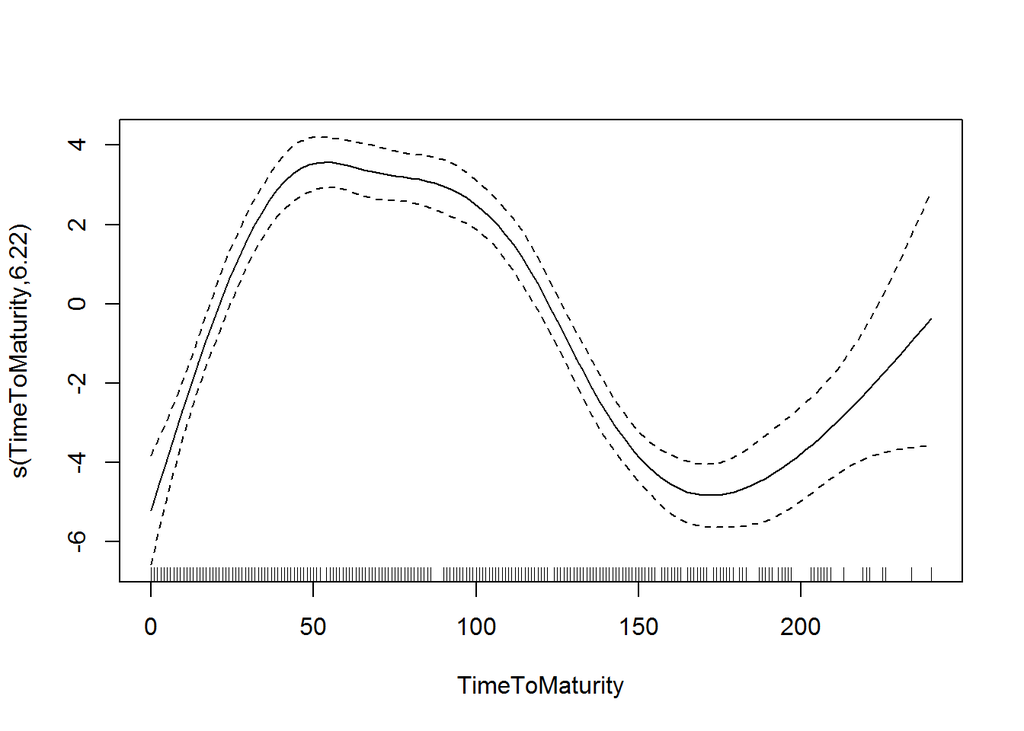

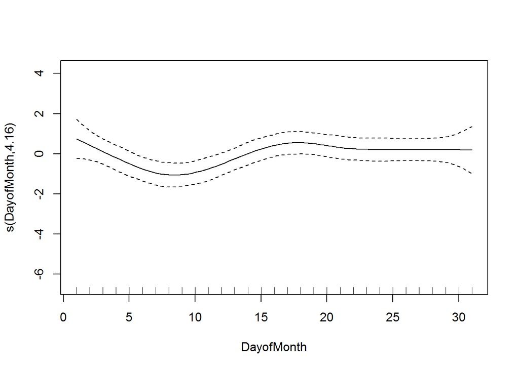

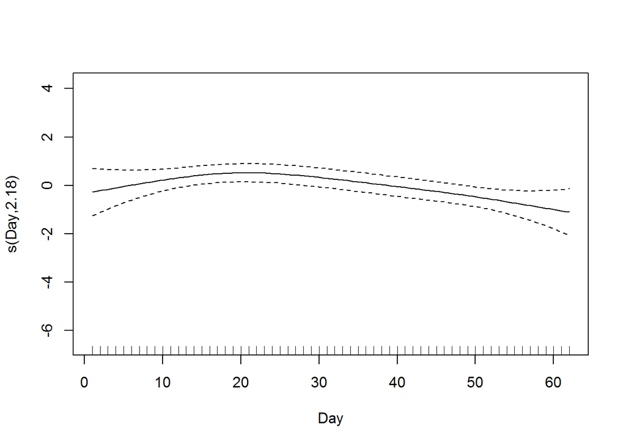

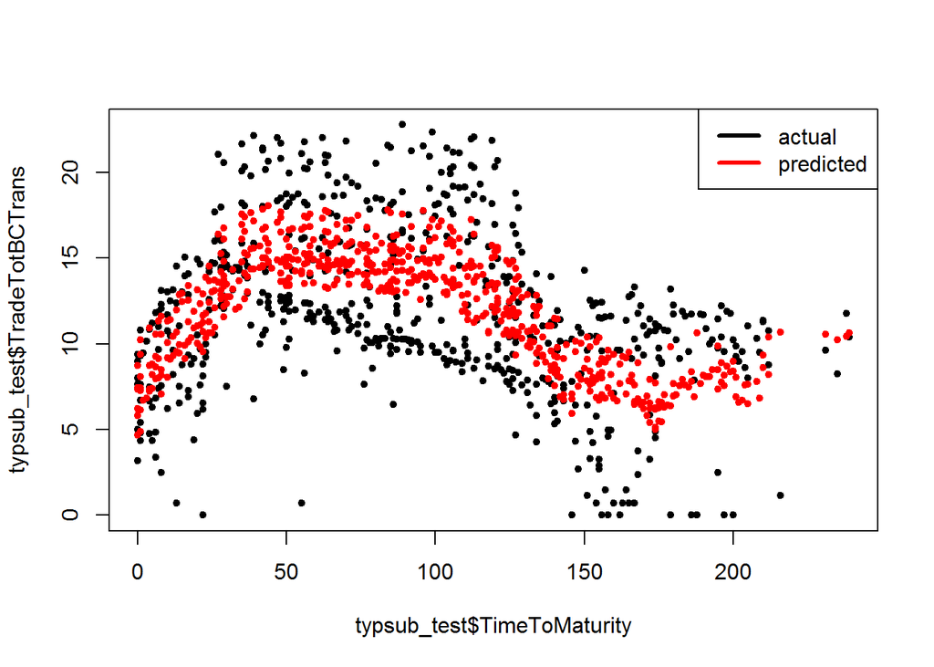

[36 more figures not shown]

```r
MAEmult_mod=c()
all_products=c()
all_medians=c()
all_MAE=c()
count=0
for (type in types){
  count=count+1
  typsub=subset(train, ProductType==type)
  model <- gam(TradeTotBCTrans ~ s(TimeToMaturity, bs="cr") + s(DayofMonth, bs="cr") + s(Day, bs="cr") + factor(ProductName) + factor(DayOfTheWeek), family=gaussian(), data = typsub, method="GCV.Cp", select=TRUE)

  typsub_test=subset(test, ProductType==type)
  testPred <- predict(model, typsub_test)
  cat(type)
  print(summary(model))
  plot(model)
  typsub_test["Prediction"]=testPred
  plot(typsub_test$TimeToMaturity, typsub_test$TradeTotBCTrans, pch=20, ylim=c(min(typsub_test$TradeTotBCTrans, typsub_test$Prediction), max(typsub_test$TradeTotBCTrans, typsub_test$Prediction)))
  points(typsub_test$TimeToMaturity, typsub_test$Prediction, col="red", pch=20)
  legend("topright", c("actual", "predicted"),lwd=c(3,3),col=c("black", "red"))
  plot(typsub_test$Day, typsub_test$TradeTotBCTrans, pch=20, ylim=c(min(typsub_test$TradeTotBCTrans, typsub_test$Prediction), max(typsub_test$TradeTotBCTrans, typsub_test$Prediction)))
  points(typsub_test$Day, typsub_test$Prediction, col="red", pch=20)

  typsub_new=subset(new_data1, ProductType==type)
  new_data1Pred <- predict(model, typsub_new)
  typsub_new["Prediction"]=new_data1Pred
  cat(type)
  plot(typsub_new$TimeToMaturity, typsub_new$TradeTotBCTrans, pch=20, ylim=c(min(typsub_new$TradeTotBCTrans, typsub_new$Prediction), max(typsub_new$TradeTotBCTrans, typsub_new$Prediction)))
  points(typsub_new$TimeToMaturity, typsub_new$Prediction, col="red", pch=20)
  legend("topright", c("actual", "predicted"),lwd=c(3,3),col=c("black", "red"))
  plot(typsub_new$Day, typsub_new$TradeTotBCTrans, pch=20, ylim=c(min(typsub_new$TradeTotBCTrans, typsub_new$Prediction), max(typsub_new$TradeTotBCTrans, typsub_new$Prediction)))
  points(typsub_new$Day, typsub_new$Prediction, col="red", pch=20)
  MAEmult_mod[count]= mean(abs(typsub_new$TradeTotBCTrans-typsub_new$Prediction))

  typsub_newT=typsub_new[rep(1,2200),]
  set.seed(1-13-17)
  typsub_newT['Day']=sample(rep(1:140, 16)[1:2200], 2200)
  print(head(typsub_newT))
  new_data1PredT <- predict(model, typsub_newT)
  typsub_newT["Prediction"]=new_data1PredT
  legend("topright", c("actual", "predicted"),lwd=c(3,3),col=c("black", "red"))
  plot(typsub_newT$Day, typsub_newT$TradeTotBCTrans, pch=20, ylim=c(min(typsub_newT$TradeTotBCTrans, typsub_newT$Prediction), max(typsub_newT$TradeTotBCTrans, typsub_newT$Prediction)))
  points(typsub_newT$Day, typsub_newT$Prediction, col="red", pch=20)

  MAEmult_modP=c()
  medianP=c()
  countP=0
  products=as.vector(unique(typsub_new$ProductName))
  all_products=append(all_products,products,length(all_products))
  for (product in products){
      countP=countP+1
      prodsub=subset(typsub_new, ProductName==product)
      MAEmult_modP[countP]= mean(abs(prodsub$TradeTotBCTrans-prodsub$Prediction))
      medianP[countP]=median(prodsub$TradeTotBCTrans)
  }
  all_MAE=append(all_MAE,MAEmult_modP,length(all_MAE))
  all_medians=append(all_medians, medianP, length(all_medians))
}
```

```r
data.frame(types, MAEmult_mod, MAEone_mod, median=medians) #separate models for each product type
```

```
##    types MAEmult_mod MAEone_mod    median
## 1  Metal    4.639196   3.648291  7.988823
## 2   Bond    3.977577   3.154708 12.190952
## 3    Agr   29.894898   1.986525 11.668960
## 4 Energy    2.984164   2.087969 11.869997
## 5  Index   22.725025   5.499198  9.882891
## 6     FX    5.270919   4.051011 13.073397
```

```r
data.frame(all_products, MAE=all_MAE, median=all_medians)
```

```
##    all_products       MAE    median
## 1            SI  4.601875  7.356573
## 2            GC  4.670567  9.198008
## 3            ZN  5.193134 17.162165
## 4            ZT  4.471700 15.321273
## 5            ZF  4.898635 17.732469
## 6            ZB  4.383485 12.357477
## 7            HO  3.120481 11.082707
## 8            ZQ  3.475675 11.967761
## 9            UB  4.241798 15.628825
## 10           ZL 27.455251 11.079648
## 11           ZM 29.565085 11.010611
## 12           ZC 32.464731 14.200150
## 13           KE 30.445966  9.829555
## 14           ZW 30.345890 13.247225
## 15           CL  3.333918 13.838677
## 16           RB  2.618925 11.100576
## 17           NG  3.124793 11.554323
## 18           NQ 20.599722  7.914951
## 19           ES 26.397909  9.779657
## 20           YM 20.002242 16.700766
## 21           GE  5.211201 14.052336
## 22           6E  5.324196  8.555509
```